# Notebook

[Sebastian Raschka](http://sebastianraschka.com)

- [Open in IPython nbviewer](http://nbviewer.ipython.org/github/rasbt/One-Python-benchmark-per-day/blob/master/ipython_nbs/day19_izip_and_xrange.ipynb)
- [Link to this IPython notebook on Github](https://github.com/rasbt/One-Python-benchmark-per-day/blob/master/ipython_nbs/day19_izip_and_xrange.ipynb)
- [Link to the GitHub Repository One-Python-benchmark-per-day](https://github.com/rasbt/One-Python-benchmark-per-day)

```python
%load_ext watermark
```

```python
%watermark -d -v -u
```

```
Last updated: 20/07/2014

CPython 2.7.8
IPython 2.1.0
```

[More information](http://nbviewer.ipython.org/github/rasbt/python_reference/blob/master/ipython_magic/watermark.ipynb) about the `watermark` magic command extension.

I would be happy to hear your comments and suggestions.  
Please feel free to drop me a note via [twitter](https://twitter.com/rasbt), , or [google+](https://plus.google.com/+SebastianRaschka).

# Day 19 - One Python Benchmark per Day

## Python 2.x's izip and xrange

A common use-case for the `range` function is the classic for-loop. In Python 2.x, `range` will create a list in memory and iterate over it. As you can imagine, its is not always very efficient to create a list (especially for a large number of iterations) if we just want to use it once.  
Thus, the `xrange` function was added later-on, which evaluates "lazily" similar to generators.  
(In Python 3.x, the `range` function was implemented similar to Python's `xrange`).

But note that it using `xrange` instead of `range` does not always make sense. E.g., if we have a use-case where we want to iterate over the sequence (here: integers) multiple times, it would be more efficient to use `range`, since `xrange` is always constructing the values from scratch.  
And also slicing is not supported by `xrange`.

```python
print 'range', type(range(3))
print 'xrange', type(xrange(3))
```

```
range <type 'list'>
xrange <type 'xrange'>
```

```
for i in range(some_int):
    pass
```

Similar to the `xrange` function, the `izip` function (in the `itertools` built-in module) evaluates the values in a list "lazily" without constructing a list of tuples like it's `zip` counterpart.

```python
from itertools import izip

print 'zip', type(zip([1,2], [3,4]))
print 'izip', type(izip([1,2], [3,4]))
```

```
zip <type 'list'>
izip <type 'itertools.izip'>
```

Also here, we take a look at the speed benefits of using `izip` over `zip` for a simple for-loop construct:

[output not shown]

# Bechmarking via `timeit`

```python
import timeit

xrange_list, range_list, zip_list, izip_list = [], [], [], []

orders = [10**i for i in xrange(1, 9)]

for n in orders:

    print('n=%s (%s of %s)' %(n, orders.index(n)+1, len(orders)))

    range_list.append(min(timeit.Timer('for i in range(n): pass' ,
            'from __main__ import n').repeat(repeat=5, number=1)))

    xrange_list.append(min(timeit.Timer('for i in xrange(n): pass' ,
            'from __main__ import n').repeat(repeat=5, number=1)))
    zip_list.append(min(timeit.Timer('for i in zip(range(n), range(n)): pass' ,
            'from __main__ import n').repeat(repeat=5, number=1)))
    izip_list.append(min(timeit.Timer('for i in izip(range(n), range(n)): pass' ,
            'from __main__ import n, izip').repeat(repeat=5, number=1)))
print('finished')
```

```
n=10 (1 of 8)
n=100 (2 of 8)
n=1000 (3 of 8)
n=10000 (4 of 8)
n=100000 (5 of 8)
n=1000000 (6 of 8)
n=10000000 (7 of 8)
n=100000000 (8 of 8)
finished
```

```python
%matplotlib inline
```

```python
from matplotlib import pyplot as plt

def plot():

    def settings():
        plt.xlim([min(orders) / 10, max(orders)* 10])
        plt.grid()
        plt.xticks(fontsize=16)
        plt.yticks(fontsize=16)
        plt.xscale('log')
        plt.yscale('log')
        plt.legend(loc='upper left', fontsize=14)
        plt.xlabel('size of n', fontsize=16)
        plt.ylabel('time in seconds (log-scale)', fontsize=16)

    fig = plt.figure(figsize=(14,6))

    plt.subplot(1,2,1)
    plt.plot(orders, range_list, label='range(n)')
    plt.plot(orders, xrange_list, label='xrange(n)')
    plt.title('range and xrange in a for-loop', fontsize=22)
    settings()

    plt.subplot(1,2,2)
    plt.plot(orders, zip_list, label='zip(n, n)')
    plt.plot(orders, izip_list, label='izip(n, n)')
    plt.title('zip and izip in a for-loop', fontsize=22)
    settings()

    plt.tight_layout()
    plt.show()
```

# Results

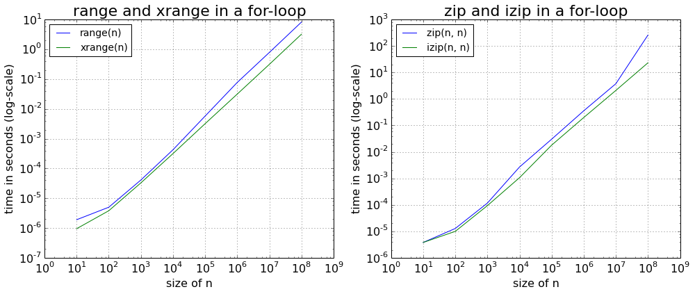

```python
plot()
```

```python
%watermark -d -v -m
```

```
20/07/2014

CPython 2.7.8
IPython 2.1.0

compiler   : GCC 4.2.1 (Apple Inc. build 5577)
system     : Darwin
release    : 13.3.0
machine    : x86_64
processor  : i386
CPU cores  : 2
interpreter: 64bit
```

If we take the logarithmic scale, the "lazy evaluation" really pays off in simple for-loop constructs where we are only iterating over a given sequence once. Especially with increasing sizes of `n`, we can obeserve that the construction of the list objects via `range` and `zip` becomes very inefficient for a one-time iteration use-case.